# Creating a Table, Exporting

## Intro

All **gt** tables begin with a call to `gt()`, where we would supply the input data table (data frame or tibble) and some basic options for creating a stub (`rowname_col`) and row groups (`groupname_col`). We can also introduce a grouped tibble (via **dplyr**’s `group_by()`) for more precise divisions of rows into row groups.

The `gt_preview()` function is great for getting a nicely-formatted preview of a data table (defaulting to the first 5 rows and the last row).

Finally, sometimes we want to export the table to some format. It could be HTML, it could be RTF… whichever you go with, you can use the `gtsave()` function.

### Functions in this module

- `gt()`
- `gt_preview()`
- `gtsave()`

### `gt()`: Create a **gt** table object

This is a preview of all the arguments in the `gt()` function:

```r
gt(
  data,
  rowname_col = "rowname",
  groupname_col = dplyr::group_vars(data),
  process_md = FALSE,
  caption = NULL,
  rownames_to_stub = FALSE,
  row_group_as_column = FALSE,
  auto_align = TRUE,
  id = NULL,
  locale = NULL,
  row_group.sep = getOption("gt.row_group.sep", " - ")
)
```

The `gt()` function creates a **gt** table object when provided with table data. Using this function is the first step in a typical **gt** workflow. Once we have the **gt** table object, we can perform styling transformations before rendering to a display table of various formats.

##### EXAMPLES

The **gt** package contains a few datasets:

- `countrypops` - Yearly populations of countries from 1960 to 2017
- `sza` - Twice hourly solar zenith angles by month & latitude
- `gtcars` - Deluxe automobiles from the 2014-2017 period
- `sp500` - Daily S&P 500 Index data from 1950 to 2015
- `pizzaplace` - A year of pizza sales from a pizza place
- `exibble` - A toy example tibble for testing with **gt**: `exibble`
- `towny` - Populations of all municipalities in Ontario from 1996 to 2021
- `metro` - The stations of the Paris Metro
- `rx_adsl` - An ADSL-flavored clinical trial toy dataset
- `rx_addv` - An ADDV-flavored clinical trial toy dataset

We will use `exibble` frequently during this workshop simply because the entire table easily fits on a screen and contains various types of data (i.e., it’s ideal for examples).

Let’s print out `exibble` and see what it looks like:

```r
exibble #This is our dataset (in the gt pkg)
```

```
## # A tibble: 8 × 9
##           num char       fctr  date       time  datetime    currency row   group
##         <dbl> <chr>      <fct> <chr>      <chr> <chr>          <dbl> <chr> <chr>
## 1       0.111 apricot    one   2015-01-15 13:35 2018-01-01…    50.0  row_1 grp_a
## 2       2.22  banana     two   2015-02-15 14:40 2018-02-02…    18.0  row_2 grp_a
## 3      33.3   coconut    three 2015-03-15 15:45 2018-03-03…     1.39 row_3 grp_a
## 4     444.    durian     four  2015-04-15 16:50 2018-04-04… 65100    row_4 grp_a
## 5    5550     <NA>       five  2015-05-15 17:55 2018-05-05…  1326.   row_5 grp_b
## 6      NA     fig        six   2015-06-15 <NA>  2018-06-06…    13.3  row_6 grp_b
## 7  777000     grapefruit seven <NA>       19:10 2018-07-07…    NA    row_7 grp_b
## 8 8880000     honeydew   eight 2015-08-15 20:20 <NA>            0.44 row_8 grp_b
```

Now lets introduce `exibble` to the `gt()` function. This is a basic table.

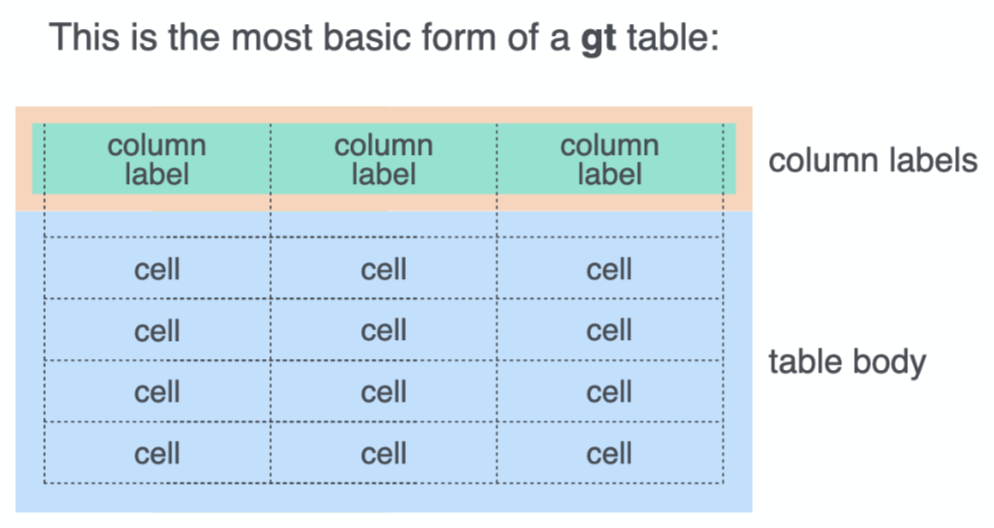

```r
exibble |> gt()
```

| num | char | fctr | date | time | datetime | currency | row | group |
| --- | --- | --- | --- | --- | --- | --- | --- | --- |
| 1.111e-01 | apricot | one | 2015-01-15 | 13:35 | 2018-01-01 02:22 | 49.950 | row_1 | grp_a |
| 2.222e+00 | banana | two | 2015-02-15 | 14:40 | 2018-02-02 14:33 | 17.950 | row_2 | grp_a |
| 3.333e+01 | coconut | three | 2015-03-15 | 15:45 | 2018-03-03 03:44 | 1.390 | row_3 | grp_a |
| 4.444e+02 | durian | four | 2015-04-15 | 16:50 | 2018-04-04 15:55 | 65100.000 | row_4 | grp_a |
| 5.550e+03 | NA | five | 2015-05-15 | 17:55 | 2018-05-05 04:00 | 1325.810 | row_5 | grp_b |
| NA | fig | six | 2015-06-15 | NA | 2018-06-06 16:11 | 13.255 | row_6 | grp_b |
| 7.770e+05 | grapefruit | seven | NA | 19:10 | 2018-07-07 05:22 | NA | row_7 | grp_b |
| 8.880e+06 | honeydew | eight | 2015-08-15 | 20:20 | NA | 0.440 | row_8 | grp_b |

```r
#This is parallel to tidykids |> ggplot(), but we're making a table instead of a plot
# {gt} stands for Grammar of Tables
```

The above is the basic layout, containing the column labels and the body cells. Numbers are minimally formatted (see the `num` column) but we can apply our own specific formatting (in the next module).

We can modify the layout a bit in the first step and create a stub. A stub is a special column that contains row labels/names. Stub:

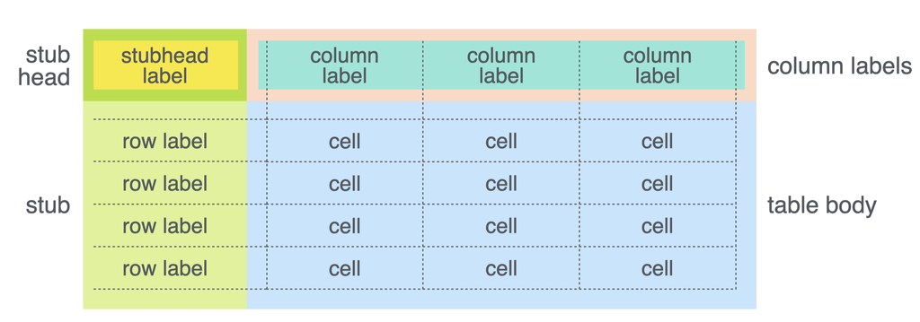

To do this, we supply the name of the column we’d like to use as the stub to the `rowname_col` argument. Conveniently, we have the `"row"` column in `exibble` that’s good for this purpose:

```r
exibble
```

```
## # A tibble: 8 × 9
##           num char       fctr  date       time  datetime    currency row   group
##         <dbl> <chr>      <fct> <chr>      <chr> <chr>          <dbl> <chr> <chr>
## 1       0.111 apricot    one   2015-01-15 13:35 2018-01-01…    50.0  row_1 grp_a
## 2       2.22  banana     two   2015-02-15 14:40 2018-02-02…    18.0  row_2 grp_a
## 3      33.3   coconut    three 2015-03-15 15:45 2018-03-03…     1.39 row_3 grp_a
## 4     444.    durian     four  2015-04-15 16:50 2018-04-04… 65100    row_4 grp_a
## 5    5550     <NA>       five  2015-05-15 17:55 2018-05-05…  1326.   row_5 grp_b
## 6      NA     fig        six   2015-06-15 <NA>  2018-06-06…    13.3  row_6 grp_b
## 7  777000     grapefruit seven <NA>       19:10 2018-07-07…    NA    row_7 grp_b
## 8 8880000     honeydew   eight 2015-08-15 20:20 <NA>            0.44 row_8 grp_b
```

```r
exibble |> gt(rowname_col = "row")
```

|  | num | char | fctr | date | time | datetime | currency | group |
| --- | --- | --- | --- | --- | --- | --- | --- | --- |
| row_1 | 1.111e-01 | apricot | one | 2015-01-15 | 13:35 | 2018-01-01 02:22 | 49.950 | grp_a |
| row_2 | 2.222e+00 | banana | two | 2015-02-15 | 14:40 | 2018-02-02 14:33 | 17.950 | grp_a |
| row_3 | 3.333e+01 | coconut | three | 2015-03-15 | 15:45 | 2018-03-03 03:44 | 1.390 | grp_a |
| row_4 | 4.444e+02 | durian | four | 2015-04-15 | 16:50 | 2018-04-04 15:55 | 65100.000 | grp_a |
| row_5 | 5.550e+03 | NA | five | 2015-05-15 | 17:55 | 2018-05-05 04:00 | 1325.810 | grp_b |
| row_6 | NA | fig | six | 2015-06-15 | NA | 2018-06-06 16:11 | 13.255 | grp_b |
| row_7 | 7.770e+05 | grapefruit | seven | NA | 19:10 | 2018-07-07 05:22 | NA | grp_b |
| row_8 | 8.880e+06 | honeydew | eight | 2015-08-15 | 20:20 | NA | 0.440 | grp_b |

Great! A bit on the *stub*. It doesn’t have a column label above it because it’s technically not a column. We can still put a label above it though, and this is done with the `tab_stubhead()` function (demo for this in the next module).

We can do some more structuring. Sets of rows can be grouped, showing a *row group label* above each group.

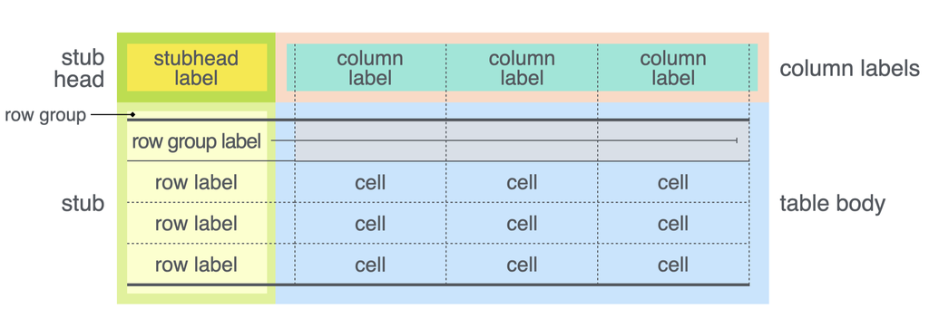

```r
exibble
```

```
## # A tibble: 8 × 9
##           num char       fctr  date       time  datetime    currency row   group
##         <dbl> <chr>      <fct> <chr>      <chr> <chr>          <dbl> <chr> <chr>
## 1       0.111 apricot    one   2015-01-15 13:35 2018-01-01…    50.0  row_1 grp_a
## 2       2.22  banana     two   2015-02-15 14:40 2018-02-02…    18.0  row_2 grp_a
## 3      33.3   coconut    three 2015-03-15 15:45 2018-03-03…     1.39 row_3 grp_a
## 4     444.    durian     four  2015-04-15 16:50 2018-04-04… 65100    row_4 grp_a
## 5    5550     <NA>       five  2015-05-15 17:55 2018-05-05…  1326.   row_5 grp_b
## 6      NA     fig        six   2015-06-15 <NA>  2018-06-06…    13.3  row_6 grp_b
## 7  777000     grapefruit seven <NA>       19:10 2018-07-07…    NA    row_7 grp_b
## 8 8880000     honeydew   eight 2015-08-15 20:20 <NA>            0.44 row_8 grp_b
```

```r
exibble |>
  gt(rowname_col = "row", groupname_col = "group")
```

|  | num | char | fctr | date | time | datetime | currency |
| --- | --- | --- | --- | --- | --- | --- | --- |
| grp_a |  |  |  |  |  |  |  |
| row_1 | 1.111e-01 | apricot | one | 2015-01-15 | 13:35 | 2018-01-01 02:22 | 49.950 |
| row_2 | 2.222e+00 | banana | two | 2015-02-15 | 14:40 | 2018-02-02 14:33 | 17.950 |
| row_3 | 3.333e+01 | coconut | three | 2015-03-15 | 15:45 | 2018-03-03 03:44 | 1.390 |
| row_4 | 4.444e+02 | durian | four | 2015-04-15 | 16:50 | 2018-04-04 15:55 | 65100.000 |
| grp_b |  |  |  |  |  |  |  |
| row_5 | 5.550e+03 | NA | five | 2015-05-15 | 17:55 | 2018-05-05 04:00 | 1325.810 |
| row_6 | NA | fig | six | 2015-06-15 | NA | 2018-06-06 16:11 | 13.255 |
| row_7 | 7.770e+05 | grapefruit | seven | NA | 19:10 | 2018-07-07 05:22 | NA |
| row_8 | 8.880e+06 | honeydew | eight | 2015-08-15 | 20:20 | NA | 0.440 |

Even if rows are in an undesirable order, **gt** will put the rows in the correct group (but still respect the order of rows).

```r
#This is a little confusing (sample_n() is used to shuffle the rows)
exibble |>
  dplyr::sample_n(size = 8) |>
  gt(rowname_col = "row", groupname_col = "group")
```

|  | num | char | fctr | date | time | datetime | currency |
| --- | --- | --- | --- | --- | --- | --- | --- |
| grp_a |  |  |  |  |  |  |  |
| row_3 | 3.333e+01 | coconut | three | 2015-03-15 | 15:45 | 2018-03-03 03:44 | 1.390 |
| row_4 | 4.444e+02 | durian | four | 2015-04-15 | 16:50 | 2018-04-04 15:55 | 65100.000 |
| row_1 | 1.111e-01 | apricot | one | 2015-01-15 | 13:35 | 2018-01-01 02:22 | 49.950 |
| row_2 | 2.222e+00 | banana | two | 2015-02-15 | 14:40 | 2018-02-02 14:33 | 17.950 |
| grp_b |  |  |  |  |  |  |  |
| row_5 | 5.550e+03 | NA | five | 2015-05-15 | 17:55 | 2018-05-05 04:00 | 1325.810 |
| row_8 | 8.880e+06 | honeydew | eight | 2015-08-15 | 20:20 | NA | 0.440 |
| row_7 | 7.770e+05 | grapefruit | seven | NA | 19:10 | 2018-07-07 05:22 | NA |
| row_6 | NA | fig | six | 2015-06-15 | NA | 2018-06-06 16:11 | 13.255 |

If you use **dplyr** then you’re probably familiar with the `group_by()` function. This will generate a grouped tibble, and you can pass that into `gt()`. The package will know what to do with a grouped tibble:

```r
exibble |>
  group_by(group) |>
  gt(rowname_col = "row")
```

|  | num | char | fctr | date | time | datetime | currency |
| --- | --- | --- | --- | --- | --- | --- | --- |
| grp_a |  |  |  |  |  |  |  |
| row_1 | 1.111e-01 | apricot | one | 2015-01-15 | 13:35 | 2018-01-01 02:22 | 49.950 |
| row_2 | 2.222e+00 | banana | two | 2015-02-15 | 14:40 | 2018-02-02 14:33 | 17.950 |
| row_3 | 3.333e+01 | coconut | three | 2015-03-15 | 15:45 | 2018-03-03 03:44 | 1.390 |
| row_4 | 4.444e+02 | durian | four | 2015-04-15 | 16:50 | 2018-04-04 15:55 | 65100.000 |
| grp_b |  |  |  |  |  |  |  |
| row_5 | 5.550e+03 | NA | five | 2015-05-15 | 17:55 | 2018-05-05 04:00 | 1325.810 |
| row_6 | NA | fig | six | 2015-06-15 | NA | 2018-06-06 16:11 | 13.255 |
| row_7 | 7.770e+05 | grapefruit | seven | NA | 19:10 | 2018-07-07 05:22 | NA |
| row_8 | 8.880e+06 | honeydew | eight | 2015-08-15 | 20:20 | NA | 0.440 |

### `gt_preview()`: Preview a **gt** table object

```r
gt_preview(
  data,
  top_n = 5,
  bottom_n = 1,
  incl_rownums = TRUE
)
```

Sometimes you may want to see just a small portion of your input data. We can use `gt_preview()` in place of `gt()` to get the first *x* rows of data and the last *y* rows of data (which can be set by the `top_n` and `bottom_n` arguments).

##### EXAMPLES

Examine the dataset `gtcars` in the {gt} package.

```r
gtcars
```

```
## # A tibble: 47 × 15
##    mfr     model     year trim  bdy_style    hp hp_rpm   trq trq_rpm mpg_c mpg_h
##    <chr>   <chr>    <dbl> <chr> <chr>     <dbl>  <dbl> <dbl>   <dbl> <dbl> <dbl>
##  1 Ford    GT        2017 Base… coupe       647   6250   550    5900    11    18
##  2 Ferrari 458 Spe…  2015 Base… coupe       597   9000   398    6000    13    17
##  3 Ferrari 458 Spi…  2015 Base  converti…   562   9000   398    6000    13    17
##  4 Ferrari 458 Ita…  2014 Base… coupe       562   9000   398    6000    13    17
##  5 Ferrari 488 GTB   2016 Base… coupe       661   8000   561    3000    15    22
##  6 Ferrari Califor…  2015 Base… converti…   553   7500   557    4750    16    23
##  7 Ferrari GTC4Lus…  2017 Base… coupe       680   8250   514    5750    12    17
##  8 Ferrari FF        2015 Base… coupe       652   8000   504    6000    11    16
##  9 Ferrari F12Berl…  2015 Base… coupe       731   8250   509    6000    11    16
## 10 Ferrari LaFerra…  2015 Base… coupe       949   9000   664    6750    12    16
## # ℹ 37 more rows
## # ℹ 4 more variables: drivetrain <chr>, trsmn <chr>, ctry_origin <chr>,
## #   msrp <dbl>
```

Use `gtcars` to create a **gt** table preview (with only a few of its columns: mfr, model, year). You’ll see the first five rows and the last row.

```r
gtcars |>
  dplyr::select(mfr, model, year) |>
  gt_preview()
```

|  | mfr | model | year |
| --- | --- | --- | --- |
| 1 | Ford | GT | 2017 |
| 2 | Ferrari | 458 Speciale | 2015 |
| 3 | Ferrari | 458 Spider | 2015 |
| 4 | Ferrari | 458 Italia | 2014 |
| 5 | Ferrari | 488 GTB | 2016 |
| 6..46 |  |  |  |
| 47 | Rolls-Royce | Wraith | 2016 |

Don’t want to see the row numbers? They can be excluded by using `incl_rownums = FALSE`.

```r
gtcars |>
  dplyr::select(mfr, model, year) |>
  gt_preview(incl_rownums = FALSE)
```

| mfr | model | year |
| --- | --- | --- |
| Ford | GT | 2017 |
| Ferrari | 458 Speciale | 2015 |
| Ferrari | 458 Spider | 2015 |
| Ferrari | 458 Italia | 2014 |
| Ferrari | 488 GTB | 2016 |
| Rolls-Royce | Wraith | 2016 |

### `gtsave()`: Save a **gt** table as a file

```r
gtsave(
  gt_object,
  filename,
  path = NULL,
  ...
)
```

The `gtsave()` function makes it easy to save a **gt** table to a file. The function assumes the output file type by the extension provided in the output filename. This will produce either an HTML, PDF, PNG, LaTeX, RTF, or docx file.

##### EXAMPLES

Use `exibble` to create a **gt** table.

```r
gt_tbl <-
  exibble |>
  gt(
    rowname_col = "row",
    groupname_col = "group"
  )

gt_tbl
```

|  | num | char | fctr | date | time | datetime | currency |
| --- | --- | --- | --- | --- | --- | --- | --- |
| grp_a |  |  |  |  |  |  |  |
| row_1 | 1.111e-01 | apricot | one | 2015-01-15 | 13:35 | 2018-01-01 02:22 | 49.950 |
| row_2 | 2.222e+00 | banana | two | 2015-02-15 | 14:40 | 2018-02-02 14:33 | 17.950 |
| row_3 | 3.333e+01 | coconut | three | 2015-03-15 | 15:45 | 2018-03-03 03:44 | 1.390 |
| row_4 | 4.444e+02 | durian | four | 2015-04-15 | 16:50 | 2018-04-04 15:55 | 65100.000 |
| grp_b |  |  |  |  |  |  |  |
| row_5 | 5.550e+03 | NA | five | 2015-05-15 | 17:55 | 2018-05-05 04:00 | 1325.810 |
| row_6 | NA | fig | six | 2015-06-15 | NA | 2018-06-06 16:11 | 13.255 |
| row_7 | 7.770e+05 | grapefruit | seven | NA | 19:10 | 2018-07-07 05:22 | NA |
| row_8 | 8.880e+06 | honeydew | eight | 2015-08-15 | 20:20 | NA | 0.440 |

Write an HTML file.

```r
gt_tbl |> gtsave("week-11/teacher/outputs/tab_1.html", inline_css = FALSE)
```

Get a PNG file (essentially a screenshot of the HTML table) by using the .png extension.

```r
gt_tbl |> gtsave("week-11/teacher/outputs/tab_r.png")
```

Get an RTF file by using the .rtf extension in the `filename`.

```r
gt_tbl |> gtsave("week-11/teacher/outputs/tab_r.rtf")
```

Get a Word file by using the .docx extension in the `filename`.

```r
gt_tbl |> gtsave("week-11/teacher/outputs/tab_r.docx")
```

### SUMMARY

1. To make a **gt** table, get your input table in the right arrangement and use `gt()`.
2. The `gt()` function has a few options for adding group rows and a *stub*.
3. If you need a quick preview of a table (regardless of the table’s size) try using `gt_preview()`
4. You can save a **gt** table in a file with `gtsave()`; you have to name the file in a supported format (e.g., `"gt_table.rtf"` for an RTF file containing the table).